# Data Analyst Skills and Salary Analysis

2026-09-09

# 1. Load the CSV and make a visualization

```r
getwd()
```

```
## [1] "/Users/vinguyen/Desktop/ITEC 4220"
```

```r
setwd("/Users/vinguyen/Desktop/ITEC 4220")

jobs <- read.csv("gsearch_jobs.csv")
head(jobs)
```

```
##   X index                                            title
## 1 0     0                                     Data Analyst
## 2 1     1                                     Data Analyst
## 3 2     2                        Aeronautical Data Analyst
## 4 3     3 Data Analyst - Consumer Goods - Contract to Hire
## 5 4     4              Data Analyst | Workforce Management
## 6 5     5                                     Data Analyst
##                 company_name           location          via
## 1                       Meta          Anywhere  via LinkedIn
## 2                        ATC   United States    via LinkedIn
## 3 Garmin International, Inc.      Olathe, KS      via Indeed
## 4                     Upwork          Anywhere    via Upwork
## 5               Krispy Kreme   United States    via LinkedIn
## 6      Flint Hills Resources     Wichita, KS        via Jora
##                                                                                                                                                                                                                                                                                                          …
```

[output cut: 62 more lines]

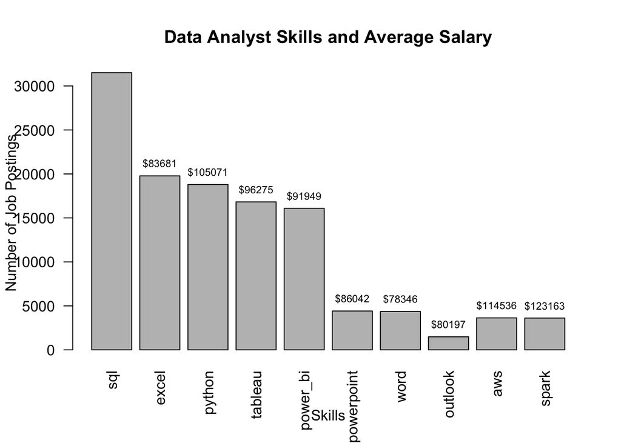

```r
skills <- c("sql", "excel", "python", "tableau", "power_bi",
            "powerpoint", "word", "outlook", "aws", "spark")

counts <- sapply(skills, function(x)
  sum(grepl(x, jobs$description_tokens)))

avg_salary <- sapply(skills, function(x)
  mean(jobs$salary_standardized[
    grepl(x, jobs$description_tokens)
  ], na.rm=TRUE))

bars <- barplot(counts,
                names.arg=skills,
                las=2,
                main="Data Analyst Skills and Average Salary",
                xlab="Skills",
                ylab="Number of Job Postings")

text(bars, counts,
     labels=paste0("$", round(avg_salary)),
     pos=3,
     cex=0.7)
```

This graph compares how frequently 10 technical skills appear in Data Analyst job postings. The height of each bar represents the number of postings mentioning the skill, while the dollar amount above each bar represents the average standardized salary for jobs mentioning that skill.

# 2. Simple Statistical Calculation

```r
jobs$python <- grepl("python", jobs$description_tokens)


python_mean <- mean(
  jobs$salary_standardized[jobs$python == TRUE],
  na.rm=TRUE
)

no_python_mean <- mean(
  jobs$salary_standardized[jobs$python == FALSE],
  na.rm=TRUE
)

python_mean
```

```
## [1] 105071.4
```

```r
no_python_mean
```

```
## [1] 88200.46
```

For this part, I calculate the average salary for jobs with and without Python. The average salary for jobs mentioning Python was approximately $105,071, while jobs not mentioning Python had salary of approximately $88,200. This suggests that Python is associated with higher-paying Data Analyst positions.

# 3. Correlation + R-square + p-value

For this part, I want to see if Data Analyst jobs with higher minimum salaries also tend to have higher maximum salaries

```r
correlation_test <- cor.test(jobs$salary_min,
         jobs$salary_max)
correlation_test
```

```
##
##  Pearson's product-moment correlation
##
## data:  jobs$salary_min and jobs$salary_max
## t = 345.14, df = 9510, p-value < 2.2e-16
## alternative hypothesis: true correlation is not equal to 0
## 95 percent confidence interval:
##  0.9608091 0.9637818
## sample estimates:
##       cor
## 0.9623242
```

```r
salary_model <- lm(salary_max ~ salary_min, data=jobs)

summary(salary_model)
```

```
##
## Call:
## lm(formula = salary_max ~ salary_min, data = jobs)
##
## Residuals:
##    Min     1Q Median     3Q    Max
## -82321  -1222  -1201  -1159 821921
##
## Coefficients:
##              Estimate Std. Error t value Pr(>|t|)
## (Intercept) 1.210e+03  2.359e+02    5.13 2.95e-07 ***
## salary_min  1.414e+00  4.097e-03  345.14  < 2e-16 ***
## ---
## Signif. codes:  0 '***' 0.001 '**' 0.01 '*' 0.05 '.' 0.1 ' ' 1
##
## Residual standard error: 18320 on 9510 degrees of freedom
##   (52441 observations deleted due to missingness)
## Multiple R-squared:  0.9261, Adjusted R-squared:  0.9261
## F-statistic: 1.191e+05 on 1 and 9510 DF,  p-value: < 2.2e-16
```

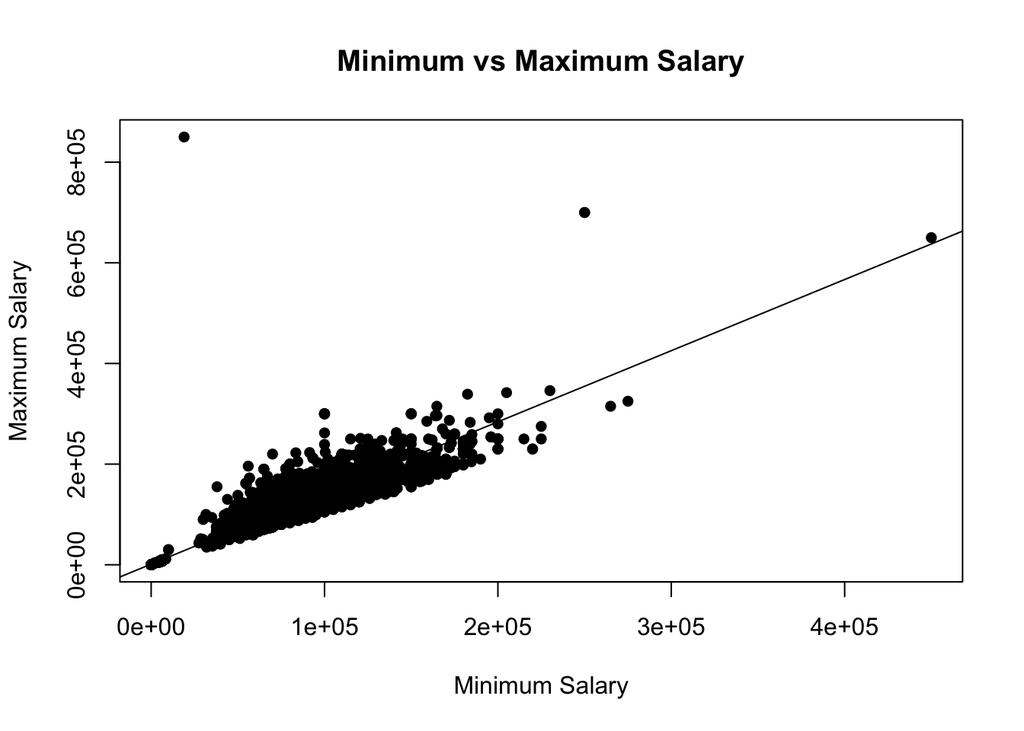

```r
plot(jobs$salary_min,
     jobs$salary_max,
     main="Minimum vs Maximum Salary",
     xlab="Minimum Salary",
     ylab="Maximum Salary",
     pch=16)

abline(salary_model)
```

The correlation between minimum and maximum salary was about 0.962. This indicated a very strong positive relationship. It means that when the minimum salary is higher, the maximum salary also tends to be higher. The p-value is less than 0.001 which indicating that the relationship is considered statistically significant, not just by random chance.

#4. Histogram of Salary

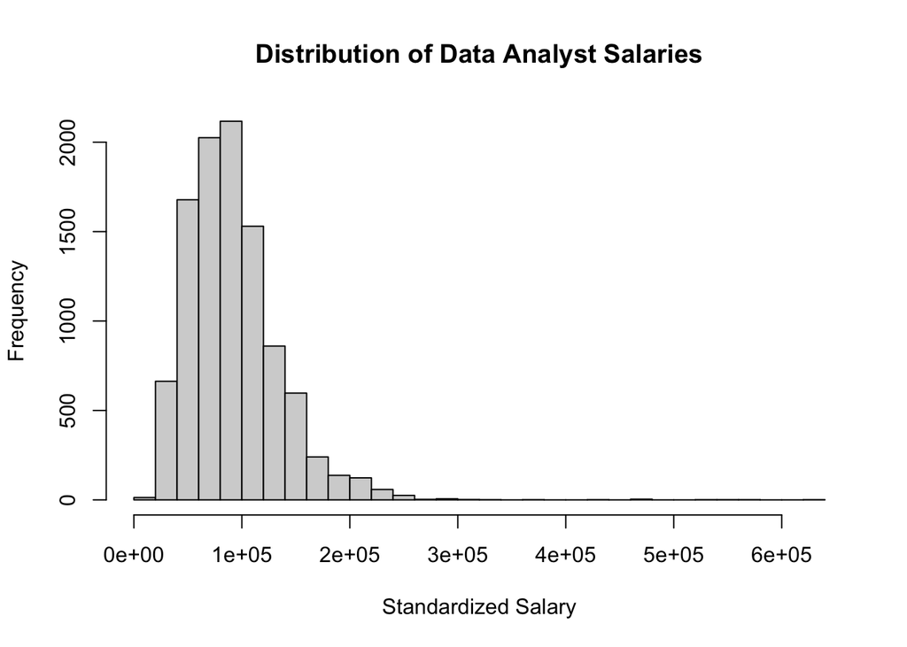

```r
hist(jobs$salary_standardized,
     main="Distribution of Data Analyst Salaries",
     xlab="Standardized Salary",
     ylab="Frequency",
     breaks=30)
```

Most job salaries are concentrated in the lower and middle salary ranges, while a smaller number of jobs have a very high salaries. This makes the graph distribution right-skewed.

# 5. T-Test

For this part, I want to see if working from home/remote jobs have a different average salary than non-remote jobs. I divided the jobs into 2 groups: work-from-home jobs and jobs not mentioned work-from-home. I use the Welch two sample t-test to compare their average salaries.

```r
t.test(salary_standardized ~ work_from_home, data=jobs)
```

```
##
##  Welch Two Sample t-test
##
## data:  salary_standardized by work_from_home
## t = -0.49316, df = 9026.5, p-value = 0.6219
## alternative hypothesis: true difference in means between group  and group True is not equal to 0
## 95 percent confidence interval:
##  -2090.910  1250.309
## sample estimates:
##     mean in group  mean in group True
##           92026.53           92446.83
```

There From the result, the average salaries for work-from-home was about $92,447, while the average salaries for non-work-from-home jobs was $92,027. The difference was about $420. The p-value was 0.6219, which is much higher than the significant level of 0.05. The result suggests that there is no statistically significant difference in average salary between work-from-home and non-work-from-home Data Analyst jobs from this dataset.